# WDS, HW 2

Group Member 1

Group Member 2

Group Member 3

Group Member 4

Group Member 5

Due: 10:00PM, Friday, July 14, 2021

# Objectives

*The main purpose for this homework is to tell the difference between probability and statistics.* Using the Roulette game as illustration, we go through the main elements of probability and statistics. We then learn how to estimate unknown parameters in a population with precision, i.e., a confidence interval. Simulations help us to understand the interpretation of a confidence interval.

- Continue to get used to `RStudio` and `RMarkdown`
- Probability
  - Random variables and their distributions
  - Population parameters: expected values and variances
  - Normal variables
  - Central limit theorem (CLT)
- Statistics
  - Sample means and sample variances
  - Use sample mean to estimate the population mean
  - Confidence intervals/hypothesis tests
- Packages/functions
  - `dplyr`
  - `ggplot`
  - `pnorm()`, `qnorm()`, `dnorm()`

# Review materials

- Study Module 2: Probability_Statistics_101

# Question 1: Probability

The following questions refer to the Red-Black Roulette game. After the ball is spun it will land in one of the slots.

1. What is the probability that the ball will land in any one slot?
2. A player will bet $1 each time. Let $X$ be the payoff.
   1. If the player bets on a single number, write down the distribution of $X$, i.e. the possible values of $X$ and the corresponding probabilities. Calculate the expected value of winning and the standard deviation.
   2. Repeat number (i) if the player bets on two numbers.
   3. If one plays the game by betting on a single number 1000 times, how much do you expect the person to win?
   4. Explain now why the casinos always make money on the roulette game.
3. Let’s “play” the game using code.
   1. We bet 30 times each round. Put 30 payoffs into a vector and store into a variable.
   2. Plot the histogram of the 30 payoffs. What is the total payoffs for this round?
   3. Let’s play another 100 rounds. Plot the histogram of total payoffs. What is the average payoff from these 100 rounds? Is this as expected?

# Question 2: Statistics (Alex attempt)

This exercise is designed to help you understand the notion of confidence interval and understand confidence interval through simulations.

Let $Y$ be the average winning amount among 100 games of betting $1 each time in the Red-Black Roulette game. We know that $Y$ follows approximately a normal distribution with mean $\mu = -.0526$ and standard deviation $\sigma = .1$. We will start to record the game payoff each time but pretend that we do not know the true mean is -.0526.

1. Generate 50 $Y's$ from $N(\mu = -.0526, \sigma =.1)$ with `set.seed(1)`. Construct a $95\%$ confidence interval for the unknown mean. State the confidence interval. Is the true value -.0526 inside the confidence interval?

```r
generateSeededConfidenceInterval <- function(x) #function to generate a confidence interval of Y with 50 trials
{
  n <- 50 #trials
  plays <- 100 #games played per trial
  set.seed(x) #seeding, more useful in part B
  win_vector <- rbinom(n, plays, 18/38) #vector of wins for 'n' trials, each trial simulating "100 'plays' games
  gain_vector <- win_vector * 2 - plays #convert wins to cash won
  avg_gain <- gain_vector / plays #convert to avg gains

  x_bar <- mean(avg_gain) #get sample mean of avg winning amt (Y) in above simulated trials
  s_error <- qnorm(0.975)*(sd(avg_gain)/sqrt(n)) #calculate standard error
  confint <- c(x_bar - s_error, x_bar + s_error) #confidence interval as vector
  return(confint)
}

ci <- generateSeededConfidenceInterval(1) #use previous function to generate first seeded ci, returns [1] -0.0819 -0.0221
```

**At 95% confidence, we generated the interval: (-0.0819, -0.0221). This successfully captures the true value of -0.0526**

2. Repeat question 2a. 100 times to generate 100 samples (each has sample size 50 and follows $N(\mu = -.0526, \sigma =.1)$) and produce 100 95% confidence intervals. How many of the confidence intervals capture the true mean -.0526? Display your 100 confidence intervals in a meaningful way.

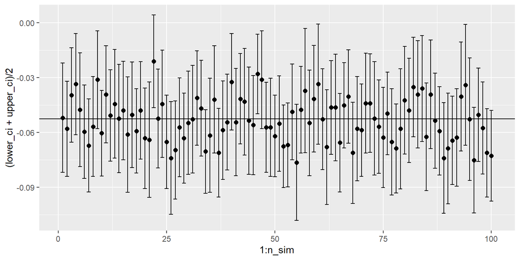

```r
n_sim <- 100 #number of simulations
upper_ci <- rep(0, n_sim) #vector filled with 0s of length n_sim storing upper cis
lower_ci <- rep(0, n_sim) #vector filled with 0s of length n_sim storing lower cis

capture_false <- 0 #counter for number of cis failing to capture true value: -0.0526

for(i in 1:n_sim) #simulate n_sim times
{
  lower_ci[i] <- first(generateSeededConfidenceInterval(i)) #set lower_ci at i to the lower confidence interval of the i'th seed
  upper_ci[i] <- last(generateSeededConfidenceInterval(i))  #set upper_ci at i to the upper confidence interval of the i'th seed
  if(lower_ci[i] > -0.056 | upper_ci[i] < -0.056) #condition testing if ci captures true value
  {
    capture_false <- capture_false + 1 #add one if failed capture
  }
}

results <- cbind(lower_ci, upper_ci) #combine to make table of cis
results_df <- as.data.frame(results) #convert results to dataframe to plot

require(ggplot2)
ggplot(results_df, aes(x = 1:n_sim, y = (lower_ci + upper_ci)/2)) + geom_point(size = 2) + geom_errorbar(aes(ymax = upper_ci, ymin = lower_ci)) + geom_hline(yintercept = -0.0526) #I'm not good with ggplot, anyone know how to color the cis that failed to capture, reorder results_df by increasing sample means (not necessary, but out of curiousity), and label the axis? Stupid questions, but thx
```

```r
cat("Number of intervals that failed to capture true value: ", capture_false) #print?
```

[output not shown]

**Out of 100 simulations run, 2 confidence intervals failed to capture the true value**

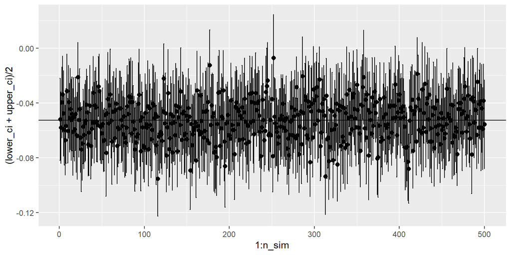

```r
n_sim <- 500 #number of simulations
upper_ci <- rep(0, n_sim) #vector filled with 0s of length n_sim storing upper cis
lower_ci <- rep(0, n_sim) #vector filled with 0s of length n_sim storing lower cis

capture_false <- 0 #counter for number of cis failing to capture true value: -0.0526

for(i in 1:n_sim) #simulate n_sim times
{
  lower_ci[i] <- first(generateSeededConfidenceInterval(i)) #set lower_ci at i to the lower confidence interval of the i'th seed
  upper_ci[i] <- last(generateSeededConfidenceInterval(i))  #set upper_ci at i to the upper confidence interval of the i'th seed
  if(lower_ci[i] > -0.056 | upper_ci[i] < -0.056) #condition testing if ci captures true value
  {
    capture_false <- capture_false + 1 #add one if failed capture
  }
}

results <- cbind(lower_ci, upper_ci) #combine to make table of cis
results_df <- as.data.frame(results) #convert results to dataframe to plot

require(ggplot2)
ggplot(results_df, aes(x = 1:n_sim, y = (lower_ci + upper_ci)/2)) + geom_point(size = 2) + geom_errorbar(aes(ymax = upper_ci, ymin = lower_ci)) + geom_hline(yintercept = -0.0526) #I'm not good with ggplot, anyone know how to color the cis that failed to capture, reorder results_df by increasing sample means (not necessary, but out of curiousity), and label the axis? Stupid questions, but thx
```

```r
cat("Number of intervals that failed to capture true value: ", capture_false) #print?
```

[output not shown]

**However, if we run the simulation 500 times instead of 100, 24 confidence intervals fail to capture the true value, meaning 476/500 did, a success rate of 0.952**

3. Summarize the interpretation of a 95% confidence interval based on the simulation in question 2b.  
   **Given a significantly large amount of confidence intervals are constructed, approximately 95% of those intervals will capture the true value.**

# Appendix: simulation code for confidence interval

To help out we provide the following R-chunk that provides 10 confidence intervals from 10 random samples. Modify it for your purpose accordingly.

```r
n_sim <- 10 # number of simulations
mu_hat <- numeric(n_sim)   # estimate
upper_ci <- numeric(n_sim)  # lower bound
lower_ci <- numeric(n_sim)  # upper bound

# Carry out the simulation
for (i in 1:n_sim){
  y <- rnorm(50, mean= -.0526, sd = .1)
  mu_hat <- mean(y)
  mu_sd < sd(y)
  upper_ci[i] <- mu_hat + 1.96 * mu_sd/sqrt(50)
  lower_ci[i] <- mu_hat - 1.96 * mu_sd/sqrt(50)
}

results <- cbind(lower_ci, upper_ci)
```